# Storm Data Analysis - Project 2

# About

This document outlines the analysis and results of Project 2 - Reproducible Research

# Introduction

This project involves exploring the U.S. National Oceanic and Atmospheric Administration’s (NOAA) storm database. This database tracks characteristics of major storms and weather events in the United States, including when and where they occur, as well as estimates of any fatalities, injuries, and property damage.

## Data Source

The data source can be downloaded from: [Storm Data](https://d396qusza40orc.cloudfront.net/repdata%2Fdata%2FStormData.csv.bz2)

## Packages Required

```r
library(downloader)
library(dplyr)
```

```r
library(ggplot2)
```

# Data Processing

describes how data is loaded and processed

## Download Data (Chante Eval to FALSE if the data has been downloaded)

```r
url<-"https://d396qusza40orc.cloudfront.net/repdata%2Fdata%2FStormData.csv.bz2"
download(url,destfile="storm.csv")
```

## Examine Sample Data

```r
test<-read.csv("storm.csv",sep = ",",nrows = 100,header = TRUE)
str(test)
```

```
## 'data.frame':    100 obs. of  37 variables:
##  $ STATE__   : num  1 1 1 1 1 1 1 1 1 1 ...
##  $ BGN_DATE  : Factor w/ 51 levels "1/20/1953 0:00:00",..: 32 32 14 49 7 7 8 2 11 11 ...
##  $ BGN_TIME  : int  130 145 1600 900 1500 2000 100 900 2000 2000 ...
##  $ TIME_ZONE : Factor w/ 1 level "CST": 1 1 1 1 1 1 1 1 1 1 ...
##  $ COUNTY    : num  97 3 57 89 43 77 9 123 125 57 ...
##  $ COUNTYNAME: Factor w/ 40 levels "BALDWIN","BARBOUR",..: 29 1 17 27 13 24 4 37 38 17 ...
##  $ STATE     : Factor w/ 1 level "AL": 1 1 1 1 1 1 1 1 1 1 ...
##  $ EVTYPE    : Factor w/ 3 levels "HAIL","TORNADO",..: 2 2 2 2 2 2 2 2 2 2 ...
##  $ BGN_RANGE : num  0 0 0 0 0 0 0 0 0 0 ...
##  $ BGN_AZI   : logi  NA NA NA NA NA NA ...
##  $ BGN_LOCATI: logi  NA NA NA NA NA NA ...
##  $ END_DATE  : logi  NA NA NA NA NA NA ...
##  $ END_TIME  : logi  NA NA NA NA NA NA ...
##  $ COUNTY_END: num  0 0 0 0 0 0 0 0 0 0 ...
```

[output cut: 23 more lines]

## Read Selected Columns

```r
storm_data<-read.csv("storm.csv",colClasses =  c(rep("NULL",7),"character",rep("NULL",14),"numeric","numeric","numeric","character","numeric","character",rep("NULL",8),"numeric"),header = TRUE,na.strings = "")
str(storm_data)
```

```
## 'data.frame':    902297 obs. of  8 variables:
##  $ EVTYPE    : chr  "TORNADO" "TORNADO" "TORNADO" "TORNADO" ...
##  $ FATALITIES: num  0 0 0 0 0 0 0 0 1 0 ...
##  $ INJURIES  : num  15 0 2 2 2 6 1 0 14 0 ...
##  $ PROPDMG   : num  25 2.5 25 2.5 2.5 2.5 2.5 2.5 25 25 ...
##  $ PROPDMGEXP: chr  "K" "K" "K" "K" ...
##  $ CROPDMG   : num  0 0 0 0 0 0 0 0 0 0 ...
##  $ CROPDMGEXP: chr  NA NA NA NA ...
##  $ REFNUM    : num  1 2 3 4 5 6 7 8 9 10 ...
```

```r
storm_data_backup<-storm_data
```

## Compute Total Crop and Property Damage

```r
table(storm_data$CROPDMGEXP)
```

```
##
##      ?      0      2      B      k      K      m      M
##      7     19      1      9     21 281832      1   1994
```

```r
#unit_conv function converts a character "K" to a numeric 1000, "M" to a numeric
# 1,000,000; and "B" to a numeric 1,000,000,000; NA to 1
unit_conv<-function(x){
        if (is.na(x)){return(NA)}
        else if (x=="K"|x=="k"){return(1000)}
        else if (x=="M"|x=="m"){return(1000000)}
        else if (x=="B"|x=="b"){return(1000000000)}
        else {
              return (NA)
        }

}
# note unit_cov is not vectorized so mapply is needed to apply to the column
unit_conv(NA)
```

```
## [1] NA
```

```r
unit_conv("b")
```

```
## [1] 1e+09
```

```r
unit_conv("m")
```

```
## [1] 1e+06
```

```r
unit_conv("k")
```

```
## [1] 1000
```

```r
unit_conv("no code")
```

```
## [1] NA
```

variable CROPDMG2 is the actual dollar amount of crop damage

```r
storm_data$CROPDMGEXP<-mapply(
        unit_conv,storm_data$CROPDMGEXP
)
storm_data<-storm_data%>%dplyr::mutate(CROPDMG2=CROPDMG*CROPDMGEXP)
```

variable PROPDMG2 stores actual dollar amount of property damage

```r
storm_data$PROPDMGEXP<-mapply(unit_conv,storm_data$PROPDMGEXP)
storm_data<-storm_data%>%dplyr::mutate(PROPDMG2=PROPDMG*PROPDMGEXP)
```

simplify the dataset by selecting only the variables needed

```r
storm_data<-dplyr::select(storm_data,-c("CROPDMG","CROPDMGEXP","PROPDMG","PROPDMGEXP"))
```

## Clean Event Type

```r
event_types<-storm_data%>%group_by(tolower(EVTYPE))%>%summarise(n=n())%>%filter(n>=1000)
head(event_types,30)
```

```
## # A tibble: 30 x 2
##    `tolower(EVTYPE)`            n
##    <chr>                    <int>
##  1 blizzard                  2719
##  2 dense fog                 1293
##  3 drought                   2488
##  4 excessive heat            1678
##  5 extreme cold/wind chill   1002
##  6 flash flood              54277
##  7 flood                    25327
##  8 frost/freeze              1343
##  9 funnel cloud              6844
## 10 hail                    288661
## # ... with 20 more rows
```

Next, we will first convert all event types to lower case, and then:

```
    * transform "high winds" to "high wind"
    * transfomr "marine tstm wind" to "marine thunderstorm wind"
    * transform "thunderstorm winds","tstm wind" to "thunderstorm wind"
    * transform "wild/forest fire" to "wildfire"
    * transform "winter weather/mix" to "winter weather
```

In addition, we transform any alternative forms to the top 10 event types

```
    * transform "hail*" to "hail"
    * transform "tornado*" to "tornado"
    * transform "flash flood*" to "flash flood"
    * transform "flood*" to "flood"
    * transform "lightning*" to "lightning"
```

```r
storm_data$EVTYPE<-tolower(storm_data$EVTYPE)
storm_data$EVTYPE<-gsub("high wind*","high wind",storm_data$EVTYPE)
storm_data$EVTYPE<-gsub("marine tstm wind*","marine thunderstorm wind",storm_data$EVTYPE)
storm_data$EVTYPE<-gsub("thunderstorm wind*|tstm wind*","thunderstorm wind",storm_data$EVTYPE)
storm_data$EVTYPE<-gsub("wild/forest fire*","wildfire",storm_data$EVTYPE)
storm_data$EVTYPE<-gsub("winter weather/mix*","winter weather",storm_data$EVTYPE)
storm_data$EVTYPE<-gsub("hail*","hail",storm_data$EVTYPE)
storm_data$EVTYPE<-gsub("tornado*","tornado",storm_data$EVTYPE)
storm_data$EVTYPE<-gsub("flash flood*","flash flood",storm_data$EVTYPE)
storm_data$EVTYPE<-gsub("flood*","flood",storm_data$EVTYPE)
storm_data$EVTYPE<-gsub("lightning*","lightning",storm_data$EVTYPE)
```

## Rationale for Data Transformation (No Code)

### Select Relevant Variables

This study focuses on two key questions:

```
    *Which types of events are most harmful to population health?
    *Which types of events have the greatest economic consequences?
```

This suggests the key information needed and its corresponding variables [reference](https://d396qusza40orc.cloudfront.net/repdata%2Fpeer2_doc%2Fpd01016005curr.pdf)

```
    *Event Type: EVTYPE
    *Harmful to Population health:
            -FATALITIES
            -INJURIES

    *Economic consequence
            -PROPDMG: property damate measured in dollar ammount
            -PROPDMGEXE: K for thousands, M for millions, B for billions
            -CROPDMG: crop damage damage measured in dollar amount
            -CROPDMGEXP: crop damage unit, coded as K, M, B same as PROPDMGEXE
    *Index
            -REFNUM: reference number
```

### Compute Total Crop and Property Damage

Since the crop damage is measured by a numeric variable and the associated unit (thousands/millions/billions), it is necessary to create two new variables:

```
    *CROPDMG: transformed to the actual dollar amount of crop damage. For example 1K will be 1000, 2M will be 2,000,000
    *PROPDMG: transformed to the actual dollar amount of property damage. For example 1K will be 1000, 2M will be 2,000,000
```

The original variables ain’t necessary and can be removed from the dataset.

### Clean Event Type

It is impractical to clean every single case so we set a rule here, if a particular type of spelling error appears 1000 times or more, we construct a strategy to fix it in the data set. In the meantime, we are looking for events with the most impact. Therefore, the threshhold is reasonable, compared to about 1 million samples.

In addition, I also cleaned the incorrect cases (by making all characters lower cases), and various forms (e.g. flooding to flood) for the top 10 event types.

# Data Analysis

## Synopsis

The data analysis includes the following steps:

```
    * Examine the processed data
    * Calculate the total fatalities, injuries, property damage, and crop damage by event type
    * Plot the top 5 most fatal event types
    * Plot the top 5 event types causing most injuries
    * Plot the top 5 event types causing most crop damage in dollar values
    * Plot the top 5 event types causing most property damages
```

## Final Examination of Processed Data

```r
head(storm_data)
```

```
##    EVTYPE FATALITIES INJURIES REFNUM CROPDMG2 PROPDMG2
## 1 tornado          0       15      1       NA    25000
## 2 tornado          0        0      2       NA     2500
## 3 tornado          0        2      3       NA    25000
## 4 tornado          0        2      4       NA     2500
## 5 tornado          0        2      5       NA     2500
## 6 tornado          0        6      6       NA     2500
```

```r
storm_data_by_EVTYPE<-storm_data%>%
        group_by(EVTYPE)%>%
        summarise(fatal_sum=sum(FATALITIES),
                  injur_sum=sum(INJURIES),
                  propdmg_sum=sum(PROPDMG2),
                  cropdmg_sum=sum(CROPDMG2))
head(storm_data_by_EVTYPE)
```

```
## # A tibble: 6 x 5
##   EVTYPE                     fatal_sum injur_sum propdmg_sum cropdmg_sum
##   <chr>                          <dbl>     <dbl>       <dbl>       <dbl>
## 1 "   high surf advisory"            0         0      200000          NA
## 2 " coastal flood"                   0         0          NA          NA
## 3 " flash flood"                     0         0       50000          NA
## 4 " lightning"                       0         0          NA          NA
## 5 " thunderstorm wind"               0         0          NA          NA
## 6 " thunderstorm wind (g45)"         0         0        8000          NA
```

### Which types of events are most harmful to population health?

### Fatalities

The top 5 storm types causing most fatalities are shown below

```r
top_5fatal<-arrange(top_n(storm_data_by_EVTYPE,5,fatal_sum),desc(fatal_sum))
```

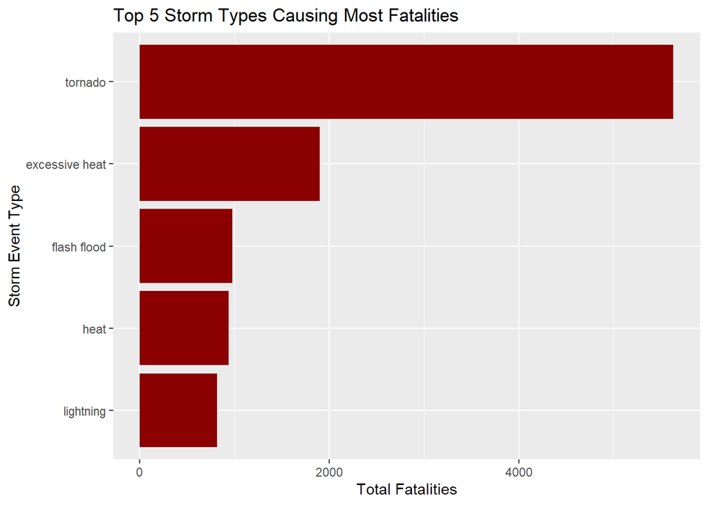

```r
ggplot2::ggplot(data=top_5fatal,aes(x=reorder(EVTYPE,fatal_sum),y=fatal_sum))+geom_bar(stat = "identity",fill="dark red")+coord_flip()+ylab("Total Fatalities")+xlab("Storm Event Type")+ggtitle("Top 5 Storm Types Causing Most Fatalities")
```

### Injuries

The top 5 storm types causing most injuries are shown below:

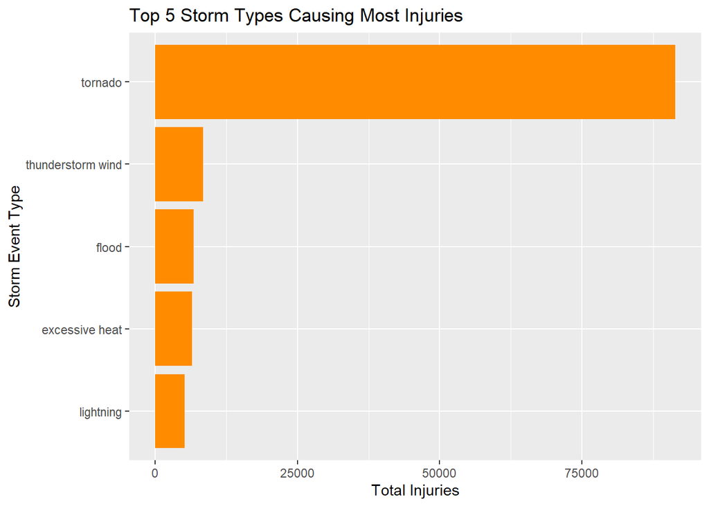

```r
top_5inj<-arrange(top_n(storm_data_by_EVTYPE,5,injur_sum),desc(injur_sum))

ggplot(data=top_5inj,aes(x=reorder(EVTYPE,injur_sum),y=injur_sum))+geom_bar(stat = "identity",fill="dark orange")+coord_flip()+ylab("Total Injuries")+xlab("Storm Event Type")+ggtitle("Top 5 Storm Types Causing Most Injuries")
```

### Crop Damages

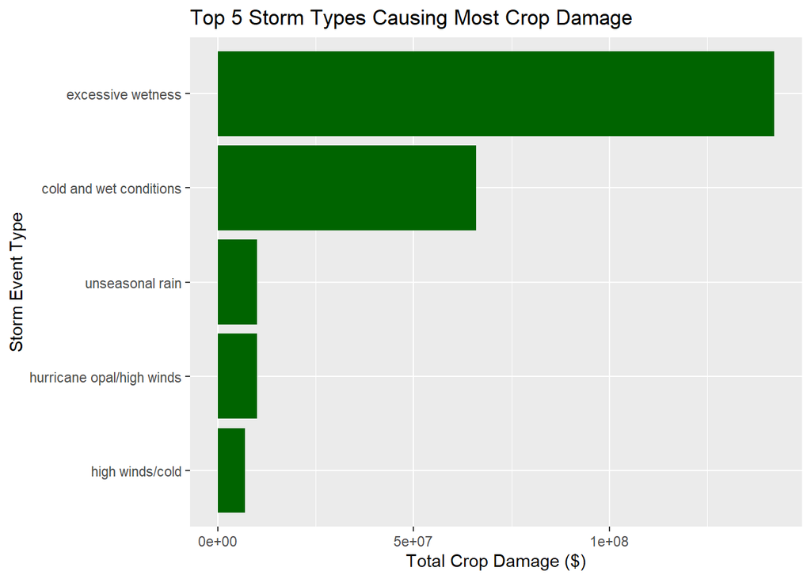

```r
top_5cropdmg<-arrange(top_n(storm_data_by_EVTYPE,5,cropdmg_sum),desc(cropdmg_sum))

ggplot(data=top_5cropdmg,aes(x=reorder(EVTYPE,cropdmg_sum),y=cropdmg_sum))+
        geom_bar(stat = "identity",fill="dark green")+coord_flip()+ylab("Total Crop Damage ($)")+xlab("Storm Event Type")+ggtitle("Top 5 Storm Types Causing Most Crop Damage")
```

### Total Property Damage

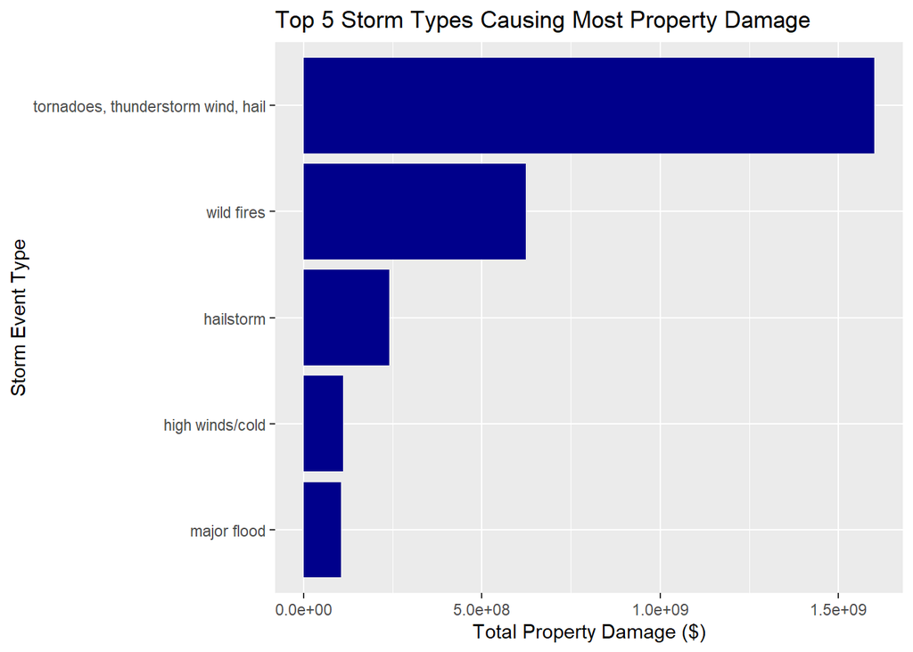

```r
top_5propdmg<-arrange(top_n(storm_data_by_EVTYPE,5,propdmg_sum),desc(propdmg_sum))



ggplot(data=top_5propdmg,aes(x=reorder(EVTYPE,propdmg_sum),y=propdmg_sum))+
        geom_bar(stat = "identity",fill="dark blue")+coord_flip()+ylab("Total Property Damage ($)")+xlab("Storm Event Type")+ggtitle("Top 5 Storm Types Causing Most Property Damage")
```